# HDVC Project

## 5. Create derived variables

### 5.1. Age groups

```r
# Define age groups
df_new <- df %>%
  mutate(age_group = cut(age,
                         breaks = c(30,39, 40, 59, 69, 79, 89),labels = c("30-39", "40-49", "50-59", "60-69", "70-79", "80-89" ),include.lowest = TRUE,right= TRUE))
```

```r
table(df_new$age_group, useNA = "ifany")
```

```
##
## 30-39 40-49 50-59 60-69 70-79 80-89
##   855    77 42194 41267 41797 41307
```

### 5.2. Factor ordering

```r
df_new <- df_new %>% mutate(
  cancer_stage = factor(cancer_stage, levels = c("Localized", "Regional", "Metastatic")),
  healthcare_access = factor(healthcare_access, ordered = FALSE),
  country = factor(country)
)
```

The categorical variables from above have been converted to factors and ordered when neccessary like cancer stages from Localized to Metastatic, in order to ensure consistent and clinically meaningful presentation in further plotting.

## 6. Bivariate exploration

### 6.1. Stage by age group

```r
stage_age_table <- df_new %>% group_by(age_group, cancer_stage) %>% summarise(count = n()) %>% mutate(percent = count / sum(count) *100)
print(stage_age_table)
```

```
## # A tibble: 18 × 4
## # Groups:   age_group [6]
##    age_group cancer_stage count percent
##    <fct>     <fct>        <int>   <dbl>
##  1 30-39     Localized      322    37.7
##  2 30-39     Regional       344    40.2
##  3 30-39     Metastatic     189    22.1
##  4 40-49     Localized       28    36.4
##  5 40-49     Regional        32    41.6
##  6 40-49     Metastatic      17    22.1
##  7 50-59     Localized    16692    39.6
##  8 50-59     Regional     16967    40.2
##  9 50-59     Metastatic    8535    20.2
## 10 60-69     Localized    16577    40.2
## 11 60-69     Regional     16427    39.8
## 12 60-69     Metastatic    8263    20.0
## 13 70-79     Localized    16621    39.8
## 14 70-79     Regional     16752    40.1
## 15 70-79     Metastatic    8424    20.2
## 16 80-89     Localized    16559    40.1
## 17 80-89     Regional     16459    39.8
## 18 80-89     Metastatic    8289    20.1
```

### 6.2. Stage by country

```r
stage_by_country_table <- df_new %>% group_by(country, cancer_stage) %>% summarise(count = n()) %>% mutate(percent = count / sum(count) *100)
# Metastatic proportion by country
metastatic_country <- stage_by_country_table %>% filter(cancer_stage == "Metastatic") %>% arrange(desc(percent))

metastatic_country
```

```
## # A tibble: 16 × 4
## # Groups:   country [16]
##    country      cancer_stage count percent
##    <fct>        <fct>        <int>   <dbl>
##  1 Australia    Metastatic    1430    20.8
##  2 Italy        Metastatic    1815    20.6
##  3 Canada       Metastatic    1814    20.6
##  4 Brazil       Metastatic    2137    20.6
##  5 Germany      Metastatic    2519    20.5
##  6 China        Metastatic    3581    20.4
##  7 Nigeria      Metastatic     717    20.2
##  8 UK           Metastatic    2473    20.1
##  9 France       Metastatic    2098    20.1
## 10 New Zealand  Metastatic     685    20.1
## 11 USA          Metastatic    5172    19.9
## 12 South Korea  Metastatic    2807    19.9
## 13 Japan        Metastatic    2754    19.8
## 14 South Africa Metastatic    1010    19.5
## 15 India        Metastatic    2033    19.4
## 16 Pakistan     Metastatic     672    18.9
```

When we examined the distribution of the stages by country, the proportion of metastatic diagnoses where close to 20% in most setting, with a moderst variation in between countries. This results could mean that the late stage diagnosis is not exclusive of only one region, but instead it represents a more global challenge.

# Explanatory Data Analysis

## 1. Summary tables for visualization

```r
## Summary table
table_col <- df %>%
  group_by(country, cancer_stage) %>%
  summarise(
    incidence_rate_per_100k  = mean(incidence_rate_per_100k, na.rm = TRUE),
    mortality_rate_per_100k  = mean(mortality_rate_per_100k, na.rm = TRUE),
    cases                    = n(),
    .groups = "drop"
  ) %>%
  # keep one incidence/mortality per country-gender (overall)
  group_by(country) %>%
  mutate(
    inc_overall = mean(incidence_rate_per_100k, na.rm = TRUE),
    mort_overall = mean(mortality_rate_per_100k, na.rm = TRUE)
  ) %>%
  ungroup() %>%
  select(Country = country,  cancer_stage, inc_overall, mort_overall, cases) %>%
  distinct() %>%
  # turn stages into columns of cases
  pivot_wider(
    names_from  = cancer_stage,
    values_from = cases,
    values_fill = 0
  ) %>%
  rename(
    Incidence_per_100k = inc_overall,
    Mortality_per_100k = mort_overall
  )

# Flextable
table_col %>%
  flextable() %>%
  autofit() %>%
  theme_booktabs() %>%
  bold(part = "header") %>%
  align(align = "center", part = "all") %>%
  bg(i = seq(1, nrow(table_col), 2), bg = "#f6f6f6") %>%
  color(color = "#132440") %>%
  border_outer() %>%
  border_inner()
```

| Country | Incidence_per_100k | Mortality_per_100k | Localized | Metastatic | Regional |
| --- | --- | --- | --- | --- | --- |
| Australia | 34.80918 | 17.00668 | 2,709 | 1,430 | 2,738 |
| Brazil | 34.37141 | 16.99266 | 4,140 | 2,137 | 4,122 |
| Canada | 34.47429 | 17.11292 | 3,425 | 1,814 | 3,580 |
| China | 34.70554 | 16.95186 | 6,968 | 3,581 | 6,976 |
| France | 34.45317 | 17.02307 | 4,097 | 2,098 | 4,231 |
| Germany | 34.61725 | 17.02898 | 4,909 | 2,519 | 4,830 |
| India | 34.31268 | 17.14425 | 4,227 | 2,033 | 4,219 |
| Italy | 34.46337 | 17.03019 | 3,543 | 1,815 | 3,437 |
| Japan | 34.65423 | 17.00838 | 5,515 | 2,754 | 5,655 |
| New Zealand | 34.59335 | 17.05419 | 1,350 | 685 | 1,378 |
| Nigeria | 34.48419 | 16.93684 | 1,402 | 717 | 1,432 |
| Pakistan | 34.97910 | 16.88447 | 1,417 | 672 | 1,460 |
| South Africa | 34.40203 | 16.97273 | 2,072 | 1,010 | 2,090 |
| South Korea | 34.47320 | 17.00826 | 5,631 | 2,807 | 5,669 |
| UK | 34.46835 | 16.99554 | 4,976 | 2,473 | 4,827 |
| USA | 34.54033 | 17.00242 | 10,418 | 5,172 | 10,337 |

```r
## T-tests
# compare the mean age by stage
df %>%
  select(age, survival_5_years, country, cancer_stage) %>%
  tbl_summary(
    by = cancer_stage,
    statistic = list(
      all_continuous() ~ "{mean} ({sd})",
      all_categorical() ~ "{n} ({p})"
    ),
    missing = "no"
    ) %>%
  add_p() %>%
  modify_header(label = "**Characteristic**") %>%
  modify_caption("**Characteristics by Colorectal Cancer Stage**")
```

**Characteristics by Colorectal Cancer Stage**

| **Characteristic** | **Localized** N = 66,799<sup>1</sup> | **Metastatic** N = 33,717<sup>1</sup> | **Regional** N = 66,981<sup>1</sup> | **p-value**<sup>2</sup> |
| --- | --- | --- | --- | --- |
| age | 69 (12) | 69 (12) | 69 (12) | 0.3 |
| survival_5_years | 40,068 (60) | 20,152 (60) | 40,167 (60) | 0.8 |
| country |  |  |  | 0.4 |
| Australia | 2,709 (4.1) | 1,430 (4.2) | 2,738 (4.1) |  |
| Brazil | 4,140 (6.2) | 2,137 (6.3) | 4,122 (6.2) |  |
| Canada | 3,425 (5.1) | 1,814 (5.4) | 3,580 (5.3) |  |
| China | 6,968 (10) | 3,581 (11) | 6,976 (10) |  |
| France | 4,097 (6.1) | 2,098 (6.2) | 4,231 (6.3) |  |
| Germany | 4,909 (7.3) | 2,519 (7.5) | 4,830 (7.2) |  |
| India | 4,227 (6.3) | 2,033 (6.0) | 4,219 (6.3) |  |
| Italy | 3,543 (5.3) | 1,815 (5.4) | 3,437 (5.1) |  |
| Japan | 5,515 (8.3) | 2,754 (8.2) | 5,655 (8.4) |  |
| New Zealand | 1,350 (2.0) | 685 (2.0) | 1,378 (2.1) |  |
| Nigeria | 1,402 (2.1) | 717 (2.1) | 1,432 (2.1) |  |
| Pakistan | 1,417 (2.1) | 672 (2.0) | 1,460 (2.2) |  |
| South Africa | 2,072 (3.1) | 1,010 (3.0) | 2,090 (3.1) |  |
| South Korea | 5,631 (8.4) | 2,807 (8.3) | 5,669 (8.5) |  |
| UK | 4,976 (7.4) | 2,473 (7.3) | 4,827 (7.2) |  |
| USA | 10,418 (16) | 5,172 (15) | 10,337 (15) |  |

<sup>1</sup> Mean (SD); n (%)  
<sup>2</sup> Kruskal-Wallis rank sum test; Pearson’s Chi-squared test

### 1.2. Pyramid of aggregate data by age group, gender and cancer stage

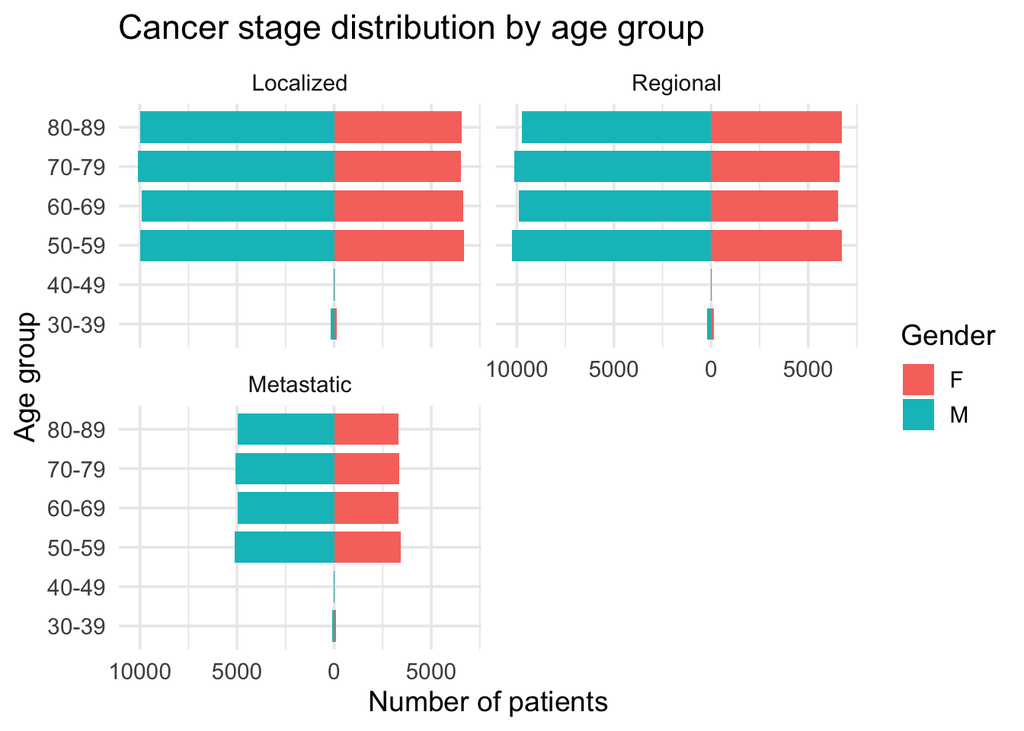

```r
# aggregate data by age group, gender and cancer stage
df_pyr <- df_new %>%
  group_by(cancer_stage, gender, age_group) %>%
  summarise(n = n(), .groups = "drop") %>%
  # signed counts, one side for each gender
  mutate(n_signed = ifelse(gender== "M", -n, n),
         # make sure age_goupu is ordered corretly
         age_group= factor(age_group, levels = sort(unique(age_group))))

# plot pyramid - split by gender, and facet bu cancer stage
ggplot(df_pyr, aes(x = age_group, y=n_signed,  fill = gender)) +
  geom_col(width = 0.8) +
  coord_flip() +
  scale_y_continuous(labels = abs) +
  facet_wrap( ~ cancer_stage, ncol = 2) +
  theme_minimal(base_size = 14) +
  labs(
    title = "Cancer stage distribution by age group",
    x = "Age group",
    y = "Number of patients",
    fill = "Gender"
  )
```

### 2.3. Cancer stage distribution by country

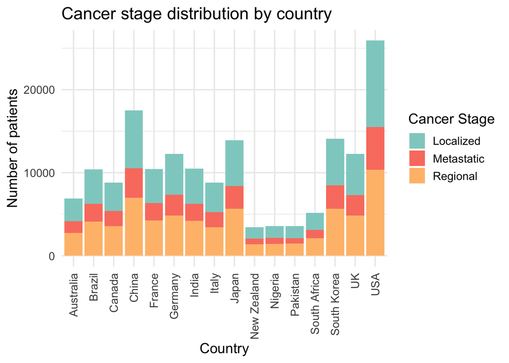

```r
ggplot(df, aes(x = country, fill = cancer_stage)) +
  geom_bar(width = 0.9) +
    scale_fill_manual(values = c("Localized" = "#8ECFC9","Regional" = "#FFBE7A","Metastatic" = "#FA7F6F"))+
  labs(
    title = "Cancer stage distribution by country",
    x = "Country",
    y = "Number of patients",
    fill = "Cancer Stage"
  ) +
  theme_minimal(base_size = 14) +
  theme(axis.text.x = element_text(angle = 90, vjust = 0.5, hjust = 1))
```

### 2.3.1 Cancer stage distribution faceted by country

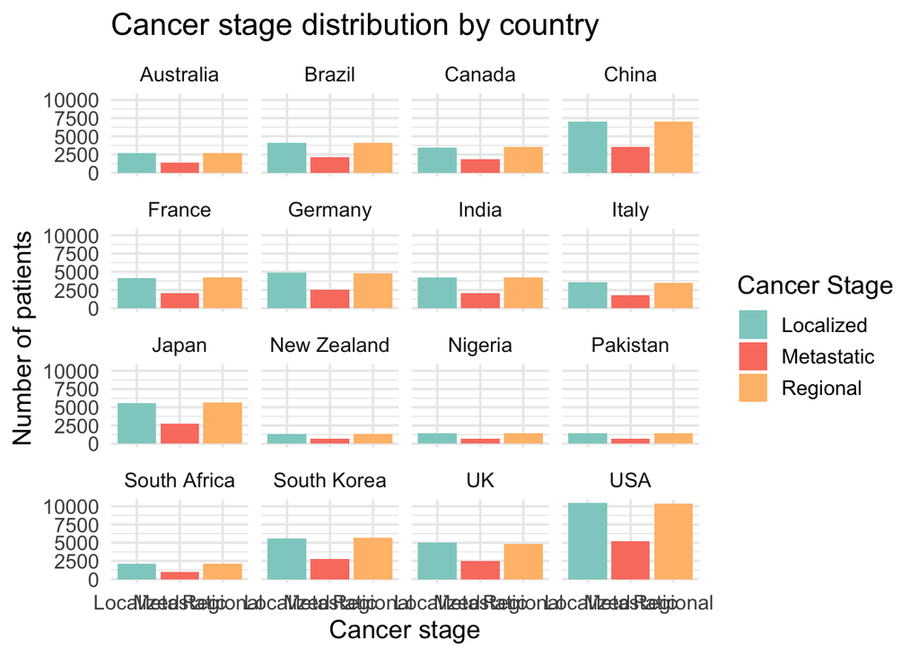

```r
# facet by country
ggplot(df, aes(x = cancer_stage, fill = cancer_stage)) +
  geom_bar() +
  scale_fill_manual(values = c("Localized" = "#8ECFC9","Regional" = "#FFBE7A","Metastatic" = "#FA7F6F"))+
  theme(axis.text.x = element_blank())+
  facet_wrap(~ country) +
  labs(
    title = "Cancer stage distribution by country",
    x = "Cancer stage",
    y = "Number of patients",
    fill = "Cancer Stage"
  ) +
  theme_minimal(base_size = 14)
```